# DATA-413/613 HW 3: Lists and Iteration

Michael Lewis

2022-09-20

# Instructions

1. Clone this homework repo to your homework directory as a new repo.
2. Rename the starter file under the analysis directory as `hw_03_yourname.Rmd` and use it for your solutions.
3. Modify the “author” field in the YAML header.
4. Stage and Commit R Markdown and HTML files (no PDF files).
5. **Push both .Rmd and HTML files to GitHub**.
- Make sure you have knitted to HTML prior to staging, committing, and pushing your final submission.
6. **Commit each time you answer a part of question, e.g. 1.1**
7. **Push to GitHub after each major question**
8. When complete, submit a response in Canvas
- Only include necessary code to answer the questions.
- Most of the functions you use should be from the tidyverse. Too much base R will result in point deductions.
- Use Pull requests and or email to ask me any questions. If you email, please ensure your most recent code is pushed to GitHub.
- **Learning Outcomes**:
  - Manipulate vectors in base-R syntax.
  - Apply iterations with for loops.

# Grading Rubric

| Question.Part: | Points | Topic |
| --- | --- | --- |
| 1.1 | 1.00 | Load the Data |
| 1.2 | 1.00 | Correct length and Names |
| 1.3 | 1.00 | Values are Removed from the list |
| 1.4 | 2.00 | Correct Posterior Mean added to scores |
| 1.5 | 2.00 | Correct Column Means added to list |
| 1.6 | 2.00 | Extracted values are correct |
| 2.1a | 2.00 | Proper Function structure |
| 2.1a | 3.00 | Complete Error checks |
| 2.1b | 1.00 | Correct Output |
| 3.1 | 1.00 | Single function with Element names and types |
| 3.2 | 3.00 | For Loop is initialized and operates correctly |
| 3.3 | 3.00 | Correct map output and Plot |
| 3.4 | 1.50 | Correct Output for pvec_f |
| 3.5 | 1.50 | Correct Output for pvec_m |
| 3.6 | 1.00 | Extra Credit |
| **Total** | **25** | plus 1 pt Extra Credit |

# 1 Working with Lists

Because of their generality, lists (or list-like objects) are often the output of many statistical procedures in R. The file `fpout.RDS` in the data folder contains sample output from using fitPoly, a statistical method to quantify properties of locations on the [genome](https://www.ncbi.nlm.nih.gov/pmc/articles/PMC5915555/).

1. Use `read_rds()` and a relative path to read this data into R.

   ```r
   library(tidyverse)
   read_rds("../data/fpout.rds") -> fpout
   ```

2. Use appropriate functions to obtain the length of the list and then the vector of the names of the elements in the list.

   ```r
   length(fpout)
   ```

   ```
   ## [1] 7
   ```

   ```r
   names(fpout)
   ```

   ```
   ## [1] "log"          "modeldata"    "allmodeldata" "scores"       "diploscores"
   ## [6] "time"         "prop_miss"
   ```

3. The `diploscores` element does not provide any information. Remove it from the list in one step.

```r
fpout[[5]] <- NULL
```

4. The `scores` element contains the output most users would want. The variables in `scores` called `P0`, `P1`, `P2`, `P3`, `P4`, `P5`, and `P6` contain “posterior probabilities” for each individual for values `0`, `1`, `2`, `3`, `4`, `5`, and `6` (respectively).
- A quantity useful in Bayesian analysis is called the “posterior mean” which in this case is calculated as follows:
  - $\text{posterior_mean] = (P0 * 0) + (P1 * 1) + (P2 * 2) + (P3 * 3) + (P4 * 4) + (P5 * 5) + (P6 * 6)$.
- Calculate the posterior mean for each individual and add this as a new variable in the `scores` data frame.

```r
fpout$scores %>%
  mutate(posterior_mean = (

  (fpout$scores$P0 * 0) + (fpout$scores$P1 * 1) + (fpout$scores$P2 * 2) +     (fpout$scores$P3 * 3) + (fpout$scores$P4 * 4) + (fpout$scores$P5 * 5) + (fpout$scores$P6 * 6)
  )
  ) -> fpout$scores
```

5. Operating on elements within a list.
- Use a {purrr} function to identify the names of the columns/variables in the `scores` data frame that are *not* of type double.
- Add a new atomic vector element called `col_means` **to the list** that contains just the column means of all the *double* variables in the `scores` data frame.

```r
#The variables that are not type double
fpout$scores %>%
  map(is.double) %>%
  keep(isFALSE)
```

```
## $marker
## [1] FALSE
##
## $MarkerName
## [1] FALSE
##
## $SampleName
## [1] FALSE
```

```r
#Adding vector element 'col_means'
fpout$scores %>%
  select_if(is.double) %>% #only dbl variables
  map_dbl(mean, na.rm = TRUE) %>%
  splice() -> col_means
  #calculate means

splice(fpout, col_means) -> fpout #bringing col_means back to fpout
fpout[[7]] -> fpout$col_means #making it the correct name
fpout[[7]] <- NULL #cleaning up

fpout$col_means
```

```
##          ratio             P0             P1             P2             P3
##   9.110837e-01  1.141826e-236   5.571926e-24   3.159587e-06   1.528993e-02
##             P4             P5             P6        maxgeno           maxP
##   2.535163e-01   5.074307e-01   2.237600e-01   4.951049e+00   9.780702e-01
##           geno posterior_mean
##   5.095652e+00   4.939654e+00
```

6. Extract elements from a list.
- Demonstrate three different ways to extract the `col_means` element from the list. The extracted element must *not be a list*.

```r
fpout[[7]]
```

```
##          ratio             P0             P1             P2             P3
##   9.110837e-01  1.141826e-236   5.571926e-24   3.159587e-06   1.528993e-02
##             P4             P5             P6        maxgeno           maxP
##   2.535163e-01   5.074307e-01   2.237600e-01   4.951049e+00   9.780702e-01
##           geno posterior_mean
##   5.095652e+00   4.939654e+00
```

```r
fpout$col_means
```

```
##          ratio             P0             P1             P2             P3
##   9.110837e-01  1.141826e-236   5.571926e-24   3.159587e-06   1.528993e-02
##             P4             P5             P6        maxgeno           maxP
##   2.535163e-01   5.074307e-01   2.237600e-01   4.951049e+00   9.780702e-01
##           geno posterior_mean
##   5.095652e+00   4.939654e+00
```

```r
fpout[["col_means"]]
```

```
##          ratio             P0             P1             P2             P3
##   9.110837e-01  1.141826e-236   5.571926e-24   3.159587e-06   1.528993e-02
##             P4             P5             P6        maxgeno           maxP
##   2.535163e-01   5.074307e-01   2.237600e-01   4.951049e+00   9.780702e-01
##           geno posterior_mean
##   5.095652e+00   4.939654e+00
```

- Show two ways to extract the third element of `col_means`

```r
fpout$col_means[3]
```

```
##           P1
## 5.571926e-24
```

```r
fpout$col_means[c("P1")]
```

```
##           P1
## 5.571926e-24
```

# 2 For Loops

Consider the recursive sequence defined by
$$x_n = x_{n-1} + \frac{|x_{n-3} - x_{n-2}|}{4}.$$
In words, element $n$ is the sum of element $n-1$ and the absolute value of the difference between between elements $n-3$ and $n-2$, divided by four. For example, if we let $x_1 = 3$, $x_2 = 1$, and $x_3 = 10$, then $x_4$ is
$$x_4 = 10 + \frac{|3 - 1|}{4} = 10.5.$$

1. Write a function called `calcn()` that takes as input a vector `x` with the first three elements of this sequence ($x_1$, $x_2$, $x_3$) and an integer `n` denoting the final element of the sequence to calculate.

   ```r
   #two inputs x (which will need to be defined as a vector), and n
   calcn <- function(x, n){

     vector(mode = "integer", length = n) -> n_length

     #Looping through the equation
   for(number in seq_along(n_length))
     {if (number <= 3)
       {n_length[number] <- x[number]
       }
       else {
         n_length[number] <- n_length[number-1] + (abs(n_length[number-3] - n_length[number-2]))/4
       }

       }
       print(n_length[n])
   }
   ```

- `calcn(x, n)` should return the value of the `n`<sup>th</sup> element.

  ```r
  #Testing on given examples
  calcn(x = c(2, 4, 3), n = 3L)
  ```

  ```
  ## [1] 3
  ```

  ```r
  calcn(x = c(2, 4, 3), n = 4L)
  ```

  ```
  ## [1] 3.5
  ```

  ```r
  calcn(x = c(2, 4, 3), n = 5L)
  ```

  ```
  ## [1] 3.75
  ```

  ```r
  calcn(x = c(2, 4, 3), n = 6L)
  ```

  ```
  ## [1] 3.875
  ```

  ```r
  calcn(x = c(2, 4, 3), n = 7L)
  ```

  ```
  ## [1] 3.9375
  ```

- Include error checking to ensure both inputs are of the correct length and class and `n` is greater than 0.

```r
calcn <- function(x, n){
  #Checking arguments: length(x) needs to be 3, x has to be an integer, and n greater than zero -- whole function is within an if statement specifying these conditions, anything else leads to error.

  if(length(x) == 3 & is.integer(n) & n > 0)  {

  vector(mode = "integer", length = n) -> n_length

  for(number in seq_along(n_length))

  {if (number <= 3)
    {n_length[number] <- x[number]
  }
    else {
      n_length[number] <- n_length[number-1] + (abs(n_length[number-3] - n_length[number-2]))/4
    }
  }

  return(n_length[n])

    } #End of function, else --> error.
  else{
    stop("Error: the provided inputs are incorrect. Check to make sure the length of x is equal to three, that x or n are both integers, and n is greater than zero.")

    }
}
```

For example, in my implementation of `calcn()`, I obtained the following:

- **Evaluate your function at the following inputs**:
  - calcn(c(11, 1, 130), 1000L)

  ```r
  calcn(c(11, 1, 130), 1000L)
  ```

  ```
  ## [1] 176.3333
  ```

  - calcn(c(11, 1, 130), 1L)

  ```r
  calcn(c(11, 1, 130), 1L)
  ```

  ```
  ## [1] 11
  ```

  - calcn(c(7, 3, 20), 8L)

  ```r
  calcn(c(7, 3, 20), 8L)
  ```

  ```
  ## [1] 26.625
  ```

```r
#Testing error
calcn(c(7, 3), 8L) #incorrect length(x)
```

```
## Error in calcn(c(7, 3), 8L): Error: the provided inputs are incorrect. Check to make sure the length of x is equal to three, that x or n are both integers, and n is greater than zero.
```

```r
calcn(c(7, 3), -8L) #n is less than zero
```

```
## Error in calcn(c(7, 3), -8L): Error: the provided inputs are incorrect. Check to make sure the length of x is equal to three, that x or n are both integers, and n is greater than zero.
```

# 3 Question: Lists, For-loops, and `map_*()`

Lists are often used to save simulation output. You can then extract individual elements from the lists using for-loops.

Consider the $t$-test, often used to test whether or not the true mean of a population for some observations is 0. We can use the following code to simulate data from a [Normal (0,1) distribution](https://en.wikipedia.org/wiki/Normal_distribution), and then use a $t$-test to test if the true mean is 0:

1. The output of `t.test()` is a list-like object. Use one function to show how many elements are in the list along with their names and class.

   ```r
   set.seed(123)
   x <- rnorm(n = 10, mean = 0, sd = 1)
   tout <- t.test(x)

   summary(tout)
   ```

   ```
   ##             Length Class  Mode
   ## statistic   1      -none- numeric
   ## parameter   1      -none- numeric
   ## p.value     1      -none- numeric
   ## conf.int    2      -none- numeric
   ## estimate    1      -none- numeric
   ## null.value  1      -none- numeric
   ## stderr      1      -none- numeric
   ## alternative 1      -none- character
   ## method      1      -none- character
   ## data.name   1      -none- character
   ```

2. Write a for-loop to perform the following three operations on iteration `i`:
   1. Draw 10 random observations from a normal distribution with mean 0 and standard deviation 2.
   2. Run a $t$-test on these 10 observations.
   3. Save the output of the $t$-test as the `i`th element in a list called `tlist`.
- Set the seed to 1 and run for 1000 iterations.

```r
set.seed(1)

tlist <- list()
for(i in 1:1000) {
 t.test(rnorm(10, mean = 0, sd = 2)) -> tout
 tout -> tlist[[i]]
}
```

3. Use the appropriate `purrr:map_*` function to extract the sample mean from each test (from 2) and pipe to an appropriate plot to show the sampling distribution of the sample mean.

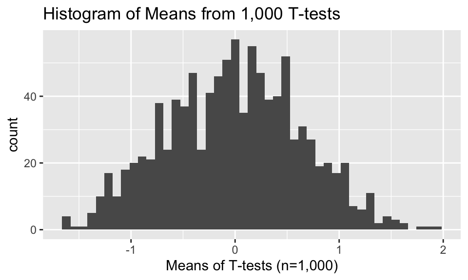

```r
#Based on t.test output the estimate section of the list is where the mean is stored ("mean of x")
tlist %>%
  map_dbl(~.$estimate) %>%
  as.data.frame() %>%

#Plot
ggplot(mapping = aes(x =.)) +
  geom_histogram(bins = 45) +
  labs(x = "Means of T-tests (n=1,000)") +
  ggtitle("Histogram of Means from 1,000 T-tests")
```

- Hint: Make sure the data going into ggplot is a data frame (tibble)
4. The $p$-value is an important quantity in statistics. Use a for-loop to extract the $p$-values from each test in part 2 and combine these $p$-values into a single atomic vector called `pvec_f`. Show the first 6 values.

```r
pvec_f <- vector(mode = "double", length = 1000)

for(i in 1:1000)
  {
tlist[[i]]$p.value -> pvec_f[[i]]
  }

head(pvec_f, n = 6)
```

```
## [1] 0.6052327 0.4806056 0.6686761 0.6480420 0.4945143 0.6653161
```

4. Use the appropriate `purrr:map_*` function to extract the $p$-values from each test in part 2 and combine these $p$-values into a single atomic vector called `pvec_m`. Show the first 6 values.

```r
tlist %>%
  map_dbl(~.$p.value) -> pvec_m

pvec_m %>%
  head(n = 6)
```

```
## [1] 0.6052327 0.4806056 0.6686761 0.6480420 0.4945143 0.6653161
```

4. *Extra Credit* $p$-values have a nice property where, if the null hypothesis is true (i.e., the mean of the observations is actually 0), then the $p$-values follow the uniform distribution.
- Use the data from `pvec_m` to create a [QQ-plot](https://en.wikipedia.org/wiki/Q–Q_plot) and then interpret the plot with regard to whether the $p$-values exhibit a uniform distribution.
- Ensure your plot has appropriate labels for the axes and a title.
- Include an abline that is dashed and colored red.

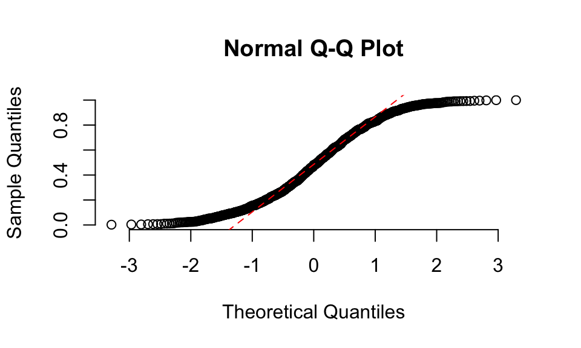

```r
#Base R Version
qqnorm(pvec_m, pch = 1, frame = FALSE)
qqline(pvec_m, col = "red", lty = 2)
```

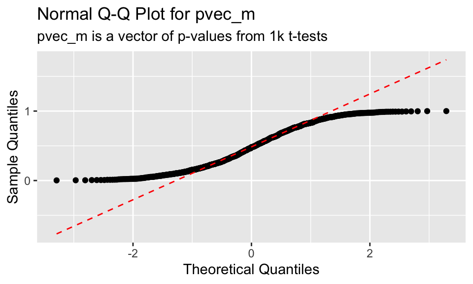

```r
#Tidyverse
pvec_m %>%
  as_tibble() %>%
  ggplot(aes(sample = value)) +
  geom_qq() +
  geom_qq_line(color = "red", linetype = 2) +
  labs(x = "Theoretical Quantiles", y = "Sample Quantiles") +
  ggtitle("Normal Q-Q Plot for pvec_m", subtitle = "pvec_m is a vector of p-values from 1k t-tests")
```